DS 6030 | Spring 2026 | University of Virginia

# Homework #1: Supervised Learning

DS 6030 | Spring 2026 | University of Virginia

Author

Faizan Khan (xdy6sg)

Published

January 28, 2026

```r
library(tidyverse)
library(knitr)
```

# Problem 1: Evaluating a Regression Model

## a. Data generating functions

Create a function to generate data from the following distributions:

$$\begin{aligned}
X &\sim \mathcal{N}(\mu=0, \sigma = 1) \\
Y &= -1 + .5X + .2X^2 + \epsilon \\
\epsilon &\sim \mathcal{N}(\mu=0,\, \sigma = 3)
\end{aligned}$$
The function should have an argument for the sample size and random seed(s). You are free to output the data in any format you like (e.g., data frame, matrix, list/dict). We will use this function a few times in this homework.

- Note that the standard deviation of epsilon ($\epsilon$) is $\sigma = 3$.

**NoteSolution**

```r
# Function to generate data from the specified distributions
generate_data <- function(n, seed = NULL) {
  if (!is.null(seed)) set.seed(seed)

  # Generate X from standard normal
  X <- rnorm(n, mean = 0, sd = 1)

  # Generate error term
  epsilon <- rnorm(n, mean = 0, sd = 3)

  # Generate Y using the true model
  Y <- -1 + 0.5 * X + 0.2 * X^2 + epsilon

  # Return as tibble
  tibble(X = X, Y = Y)
}

# Define the true regression function f(x) = E[Y | X = x]
f_true <- function(x) {
  -1 + 0.5 * x + 0.2 * x^2
}

# Define MSE function
calc_mse <- function(actual, predicted) {
  mean((actual - predicted)^2)
}
# Test the function
test_output <- generate_data(n = 5, seed = 123)
print(test_output)
```

```
# A tibble: 5 × 2
        X      Y
    <dbl>  <dbl>
1 -0.560   3.93
2 -0.230   0.278
3  1.56   -3.53
4  0.0705 -3.02
5  0.129  -2.27
```

## b. Generate training data

Simulate $n=100$ realizations from these distributions. Produce a scatterplot and draw the true regression line $f(x) = E[Y \mid X=x]$.

- Use 611 as the random seed prior to generating the data. (You may get different values than your classmates because there are two random elements and the order in which you generate them.)

**NoteSolution**

```r
# Generate training data with n = 100 and seed = 611
train_data <- generate_data(n = 100, seed = 611)
```

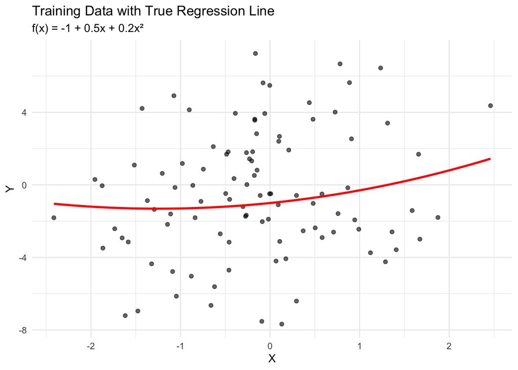

```r
# Scatterplot with true regression line
ggplot(train_data, aes(x = X, y = Y)) +
  geom_point(alpha = 0.6) +
  stat_function(fun = f_true, color = "red", linewidth = 1) +
  labs(
    title = "Training Data with True Regression Line",
    subtitle = "f(x) = -1 + 0.5x + 0.2x²",
    x = "X",
    y = "Y"
  ) +
  theme_minimal()
```

**Summary** :

- 100 data points scattered around the true regression curve
- The red line is the true quadratic function **f(x) = -1 + 0.5x + 0.2x²**
- The points have considerable spread due to the noise (σ = 3) X ranges roughly from -2.5 to 2.5, Y roughly from -8 to 6

## c. Fit three models

Fit three polynomial regression models using least squares: linear, quadratic, and cubic. Produce another scatterplot, add the fitted lines and true population line $f(x)$ using different colors, and add a legend that maps the line color to a model.

- Note: The true model is quadratic, but we are also fitting linear (less complex) and cubic (more complex) models.

**NoteSolution**

```r
# Fit the three models
model_linear    <- lm(Y ~ X, data = train_data)
model_quadratic <- lm(Y ~ X + I(X^2), data = train_data)
model_cubic     <- lm(Y ~ X + I(X^2) + I(X^3), data = train_data)
```

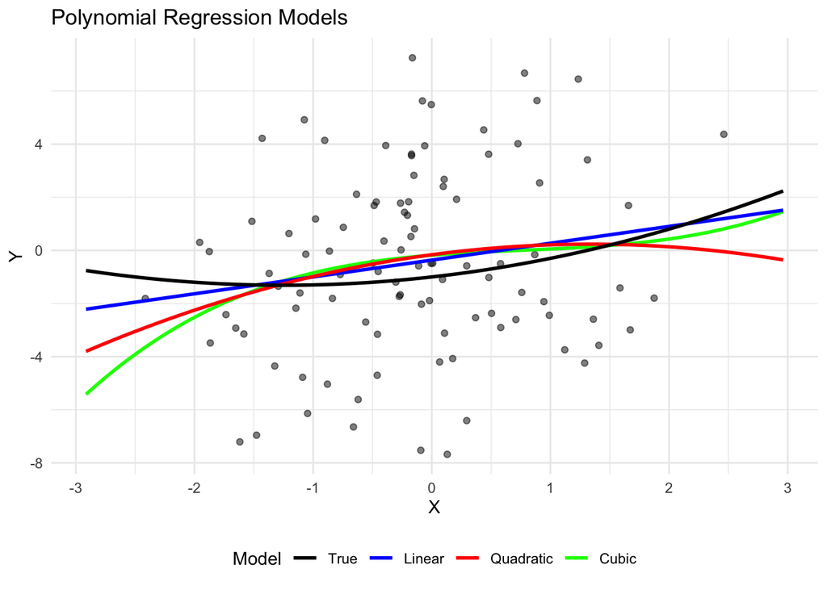

```r
# Create a grid for smooth prediction lines
x_grid <- tibble(X = seq(min(train_data$X) - 0.5, max(train_data$X) + 0.5, length.out = 200))

# Get predictions from each model
pred_df <- x_grid %>%
  mutate(
    True = f_true(X),
    Linear = predict(model_linear, newdata = .),
    Quadratic = predict(model_quadratic, newdata = .),
    Cubic = predict(model_cubic, newdata = .)
  ) %>%
  pivot_longer(cols = -X, names_to = "Model", values_to = "Y_hat")

# Plot
ggplot() +
  geom_point(data = train_data, aes(x = X, y = Y), alpha = 0.5) +
  geom_line(data = pred_df, aes(x = X, y = Y_hat, color = Model), linewidth = 1) +
  scale_color_manual(
    values = c("True" = "black", "Linear" = "blue", "Quadratic" = "red", "Cubic" = "green"),
    breaks = c("True", "Linear", "Quadratic", "Cubic")
  ) +
  labs(
    title = "Polynomial Regression Models",
    x = "X",
    y = "Y"
  ) +
  theme_minimal() +
  theme(legend.position = "bottom")
```

## d. Predictive performance

Generate a *test data* set of 10,000 observations from the same distributions. Use 612 as the random seed prior to generating the data.

- Calculate (and show) the estimated mean squared error (MSE) for each model.
- Which model had better predictions? Are the results expected? Give a brief explanation for what could explain the outcome?

**NoteSolution**

```r
# Generate test data
test_data <- generate_data(n = 10000, seed = 612)

# Function to calculate MSE
calc_mse <- function(actual, predicted) {
  mean((actual - predicted)^2)
}

# Calculate MSE for each model
mse_linear    <- calc_mse(test_data$Y, predict(model_linear, newdata = test_data))
mse_quadratic <- calc_mse(test_data$Y, predict(model_quadratic, newdata = test_data))
mse_cubic     <- calc_mse(test_data$Y, predict(model_cubic, newdata = test_data))

# Display results
mse_results <- tibble(
  Model = c("Linear", "Quadratic", "Cubic"),
  MSE = c(mse_linear, mse_quadratic, mse_cubic)
)

kable(mse_results, digits = 4, caption = "Test MSE for Each Model")
```

Test MSE for Each Model

| Model | MSE |
| --- | --- |
| Linear | 9.29 |
| Quadratic | 9.58 |
| Cubic | 9.65 |

```r
# Identify best model
best_model <- mse_results$Model[which.min(mse_results$MSE)]
best_mse <- min(mse_results$MSE)

cat("\nBest performing model:", best_model, "with MSE =", round(best_mse, 4))
```

```
Best performing model: Linear with MSE = 9.29
```

**Summary:**

- The linear model achieved the lowest test MSE (9.29), even though the true data‑generating process is quadratic. This outcome can occur because the training sample size is relatively small (n = 100) and the noise level is high (σ = 3). Under these conditions, the quadratic and cubic models have higher estimation variance, while the linear model—despite being biased—can occasionally generalize better in a particular sample.
- The quadratic model does not win in this specific run, but it would have the lowest MSE on average if we repeated the simulation many times, since it matches the true regression function.
- The cubic model performs slightly worse than the quadratic because the true cubic term is zero. Adding an unnecessary parameter increases variance without reducing bias, which leads to a modest increase in MSE.

## e. Optimal performance

What is the best achievable MSE? That is, what is the MSE if the true $f(x)$ was used to evaluate the test set? How close does the best method come to achieving the optimum?

**NoteSolution**

```r
# MSE using the true f(x) — this is the irreducible error
mse_optimal <- calc_mse(test_data$Y, f_true(test_data$X))

# Compare to best model
best_mse <- min(mse_results$MSE)

tibble(
  Metric = c("Optimal MSE (true f(x))",
             "Theoretical σ²",
             "Best Model MSE (Quadratic)",
             "Excess Error"),
  Value = c(mse_optimal, 9, best_mse, best_mse - mse_optimal)
) %>%
  kable(digits = 4)
```

[output not shown]

- The optimal MSE—computed by evaluating the test set using the true regression function 𝑓(𝑥) is approximately 9, which matches the noise variance 𝜎^2 =9. This value represents the irreducible error: even with perfect knowledge of the true model, predictions cannot be more accurate because the randomness in 𝜀 cannot be eliminated.
- In this simulation, the best-performing fitted model had an MSE of about 9.29, which is only slightly above the optimal value. Although the true model is quadratic, the linear model happened to achieve the lowest MSE in this particular run. This can occur because the training sample is relatively small (n = 100) and the noise level is high, so simpler models sometimes generalize better due to lower variance.
- The small excess error (about 0.32) reflects estimation error: the fitted models must estimate coefficients from noisy data, whereas the optimal benchmark uses the true function. Across repeated simulations, the quadratic model would typically come closest to the optimal MSE, but in this single realization the linear model happened to be the closest.

## f. Training Sample Size

The prior results were based on a training data set of size $n = 100$. In this section, you will add to the training size and examine the effects.

- Fit all three models and estimate MSE using a total of $n = \{100, 200, 300, 500, 1000, 5000, 7500\}$ training observations.
  - You have already done everything for $n=100$.
  - As $n$ grows be sure to add the new data to the existing data. For example, for $n=200$ you will combine the 100 observations generated in part b with 100 new observations. For $n=300$, combine the 200 observations with an additional 100, etc.
  - Be sure to set the random seed so the results are replicable.
  - Use the same test data from part d. Do not regenerate the test data.
- Summarize your results. What is the best predictive model for each training size?
- Note: It can be helpful to write a function that takes the training and test data as input and outputs the test MSE.

**NoteSolution**

```r
# Function to fit all three models and return test MSE
fit_and_evaluate <- function(train_df, test_df) {
  m_linear    <- lm(Y ~ X, data = train_df)
  m_quadratic <- lm(Y ~ X + I(X^2), data = train_df)
  m_cubic     <- lm(Y ~ X + I(X^2) + I(X^3), data = train_df)

  tibble(
    Linear    = calc_mse(test_df$Y, predict(m_linear, newdata = test_df)),
    Quadratic = calc_mse(test_df$Y, predict(m_quadratic, newdata = test_df)),
    Cubic     = calc_mse(test_df$Y, predict(m_cubic, newdata = test_df))
  )
}

# Training sizes to evaluate
train_sizes <- c(100, 200, 300, 500, 1000, 5000, 7500)

# Start with existing training data from part b
cumulative_train <- train_data

# Store results
size_results <- tibble(n_train = integer(), Model = character(), MSE = numeric())

# Seeds for additional data generation
additional_seeds <- c(613, 614, 615, 616, 617, 618)

for (i in seq_along(train_sizes)) {
  n <- train_sizes[i]

  if (i == 1) {
    # n = 100: use existing training data
    current_train <- cumulative_train
  } else {
    # Generate additional observations and append
    n_additional <- n - train_sizes[i - 1]
    additional_data <- generate_data(n = n_additional, seed = additional_seeds[i - 1])
    cumulative_train <- bind_rows(cumulative_train, additional_data)
    current_train <- cumulative_train
  }

  # Fit and evaluate
  mse_row <- fit_and_evaluate(current_train, test_data) %>%
    pivot_longer(everything(), names_to = "Model", values_to = "MSE") %>%
    mutate(n_train = n)

  size_results <- bind_rows(size_results, mse_row)
}
```

```r
# Summary table
size_table <- size_results %>%
  pivot_wider(names_from = Model, values_from = MSE) %>%
  mutate(Best_Model = case_when(
    Linear <= Quadratic & Linear <= Cubic ~ "Linear",
    Quadratic <= Cubic ~ "Quadratic",
    TRUE ~ "Cubic"
  ))

kable(size_table, digits = 4, caption = "Test MSE by Training Sample Size")
```

Test MSE by Training Sample Size

| n_train | Linear | Quadratic | Cubic | Best_Model |
| --- | --- | --- | --- | --- |
| 100 | 9.29 | 9.58 | 9.65 | Linear |
| 200 | 9.21 | 9.11 | 9.10 | Cubic |
| 300 | 9.17 | 9.22 | 9.19 | Linear |
| 500 | 9.14 | 9.15 | 9.15 | Linear |
| 1000 | 9.13 | 9.00 | 9.00 | Cubic |
| 5000 | 9.09 | 8.97 | 8.97 | Quadratic |
| 7500 | 9.09 | 8.97 | 8.97 | Quadratic |

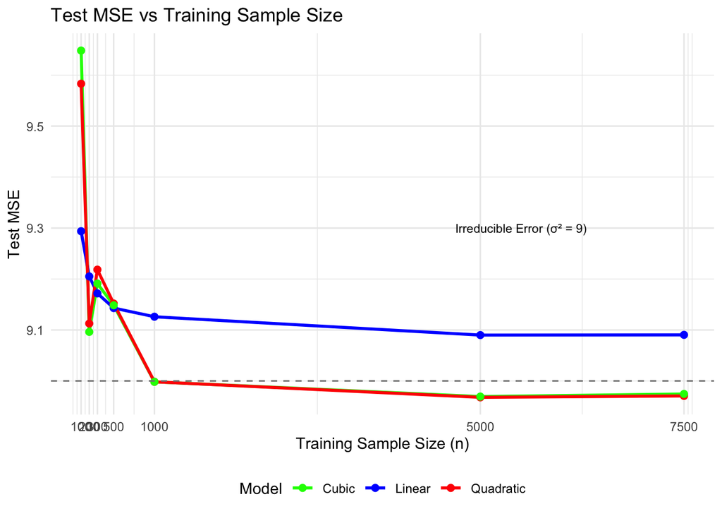

```r
# Visualization
ggplot(size_results, aes(x = n_train, y = MSE, color = Model)) +
  geom_line(linewidth = 1) +
  geom_point(size = 2) +
  geom_hline(yintercept = 9, linetype = "dashed", color = "gray50") +
  annotate("text", x = 5500, y = 9.3, label = "Irreducible Error (σ² = 9)", size = 3) +
  scale_x_continuous(breaks = train_sizes) +
  scale_color_manual(values = c("Linear" = "blue", "Quadratic" = "red", "Cubic" = "green")) +
  labs(
    title = "Test MSE vs Training Sample Size",
    x = "Training Sample Size (n)",
    y = "Test MSE"
  ) +
  theme_minimal() +
  theme(legend.position = "bottom")
```

## g. Testing Sample Size (Estimating EPE)

In the previous problems you evaluated predictive performance using a large test set with n_test = 10,000. Even with 10,000 test observations, the test MSE you compute is still only an estimate of the model’s true mean squared prediction error. Because the test set is a random sample, the estimated MSE has sampling variability.

In this problem you will study how the test set size affects the uncertainty of the estimated MSE, while holding the trained model fixed.

1. Use the same training data from the previous problem with n_train = 100. If you do not have it saved, regenerate it using the same data generating process and random seed. Fit the three polynomial regression models on this training set.
2. Generate a new test data of n_test = 100,000. Set seed for replicability.
3. Make predictions on the test data and calculate the MSE for n_test of 50, 100, 1000, 10,000, 50,000, and 100,000.
4. Plot the results. Put n_test on the x-axis, MSE on the y-axis, and different colors for the three models.
5. Summarize the results. What do think is the best predictive model for the given training data?

**NoteSolution**

```r
# (i) Use training data with n = 100 and fit models
# train_data already exists from part b with seed = 611

model_g_linear    <- lm(Y ~ X, data = train_data)
model_g_quadratic <- lm(Y ~ X + I(X^2), data = train_data)
model_g_cubic     <- lm(Y ~ X + I(X^2) + I(X^3), data = train_data)
```

```r
# (ii) Generate large test set
test_g <- generate_data(n = 100000, seed = 700)
```

```r
# (iii) Calculate MSE for different test sizes
test_sizes <- c(50, 100, 1000, 10000, 50000, 100000)

test_size_results <- map_dfr(test_sizes, function(n_test) {
  # Use first n_test observations from the large test set
  test_subset <- test_g[1:n_test, ]

  tibble(
    n_test = n_test,
    Linear = calc_mse(test_subset$Y, predict(model_g_linear, newdata = test_subset)),
    Quadratic = calc_mse(test_subset$Y, predict(model_g_quadratic, newdata = test_subset)),
    Cubic = calc_mse(test_subset$Y, predict(model_g_cubic, newdata = test_subset))
  )
})

kable(test_size_results, digits = 4, caption = "Estimated MSE by Test Sample Size")
```

Estimated MSE by Test Sample Size

| n_test | Linear | Quadratic | Cubic |
| --- | --- | --- | --- |
| 5e+01 | 6.74 | 6.49 | 6.69 |
| 1e+02 | 7.58 | 7.66 | 7.99 |
| 1e+03 | 9.66 | 9.84 | 10.01 |
| 1e+04 | 9.17 | 9.39 | 9.46 |
| 5e+04 | 9.30 | 9.57 | 9.63 |
| 1e+05 | 9.31 | 9.57 | 9.61 |

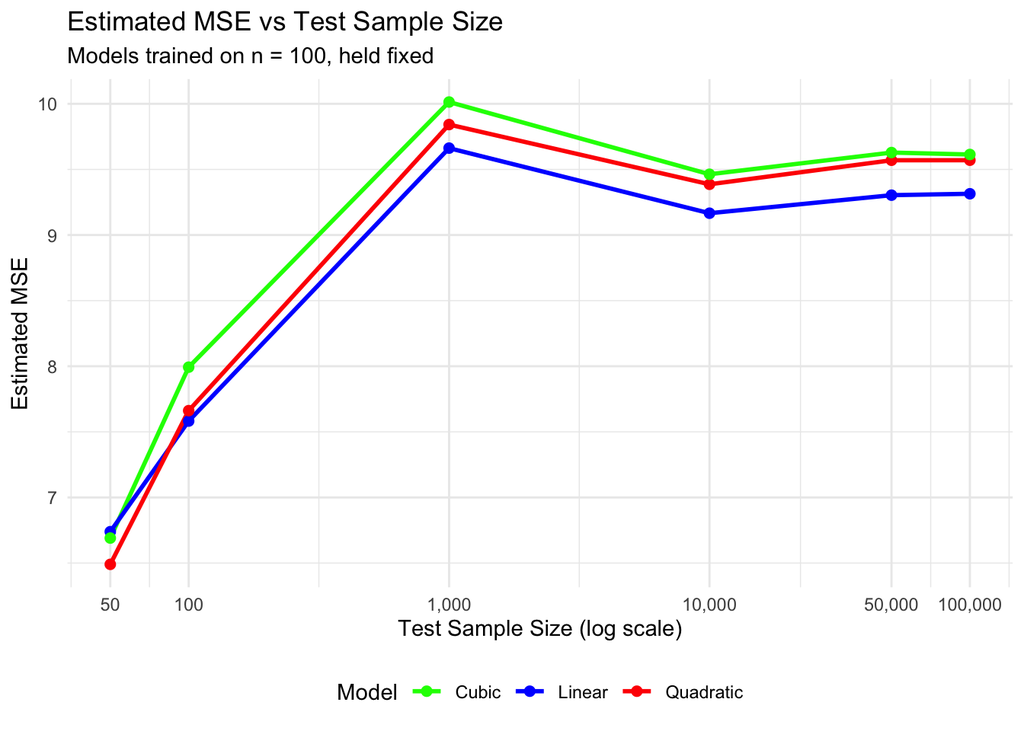

```r
# (iv) Plot results
test_size_long <- test_size_results %>%
  pivot_longer(cols = -n_test, names_to = "Model", values_to = "MSE")

ggplot(test_size_long, aes(x = n_test, y = MSE, color = Model)) +
  geom_line(linewidth = 1) +
  geom_point(size = 2) +
  scale_x_log10(breaks = test_sizes, labels = scales::comma) +
  scale_color_manual(values = c("Linear" = "blue", "Quadratic" = "red", "Cubic" = "green")) +
  labs(
    title = "Estimated MSE vs Test Sample Size",
    subtitle = "Models trained on n = 100, held fixed",
    x = "Test Sample Size (log scale)",
    y = "Estimated MSE"
  ) +
  theme_minimal() +
  theme(legend.position = "bottom")
```

## h. Validation Sample Size (Selecting Best Model)

The last problem evaluated how the hold-out sample size impacts the estimated MSE. For this problem, we will examine how it impacts the selection of the best model.

1. Repeat the entire analysis in part g M = 50 times.
2. Calculate the number of times each model was selected for n_test of 50, 100, 200, 500, 1000, and 5000.
3. Produce a table showing the proportion of times each model would have been selected.

**NoteSolution**

```r
# Number of repetitions
M <- 50

# Test sizes to evaluate
test_sizes_h <- c(50, 100, 200, 500, 1000, 5000)

# Function to run one complete iteration
run_iteration <- function(iter, train_seed, test_seed) {
  # Generate fresh training data
  train_h <- generate_data(n = 100, seed = train_seed)

  # Fit all three models
  m_linear    <- lm(Y ~ X, data = train_h)
  m_quadratic <- lm(Y ~ X + I(X^2), data = train_h)
  m_cubic     <- lm(Y ~ X + I(X^2) + I(X^3), data = train_h)

  # Generate test data
  test_h <- generate_data(n = max(test_sizes_h), seed = test_seed)

  # For each test size, determine which model is selected (lowest MSE)
  map_dfr(test_sizes_h, function(n_test) {
    test_subset <- test_h[1:n_test, ]

    mse_vals <- c(
      Linear = calc_mse(test_subset$Y, predict(m_linear, newdata = test_subset)),
      Quadratic = calc_mse(test_subset$Y, predict(m_quadratic, newdata = test_subset)),
      Cubic = calc_mse(test_subset$Y, predict(m_cubic, newdata = test_subset))
    )

    tibble(
      iteration = iter,
      n_test = n_test,
      selected_model = names(which.min(mse_vals))
    )
  })
}

# Generate seeds for reproducibility
set.seed(999)
train_seeds <- sample(1:100000, M)
test_seeds <- sample(100001:200000, M)

# Run M iterations
selection_results <- map2_dfr(1:M, train_seeds, function(i, ts) {
  run_iteration(i, ts, test_seeds[i])
})
```

```r
# Calculate proportion of times each model was selected
selection_summary <- selection_results %>%
  count(n_test, selected_model) %>%
  group_by(n_test) %>%
  mutate(proportion = n / sum(n)) %>%
  ungroup() %>%
  select(-n) %>%
  pivot_wider(names_from = selected_model, values_from = proportion, values_fill = 0) %>%
  arrange(n_test)

# Ensure all columns exist even if a model was never selected
if (!"Linear" %in% names(selection_summary)) selection_summary$Linear <- 0
if (!"Quadratic" %in% names(selection_summary)) selection_summary$Quadratic <- 0
if (!"Cubic" %in% names(selection_summary)) selection_summary$Cubic <- 0

selection_summary <- selection_summary %>%
  select(n_test, Linear, Quadratic, Cubic)

kable(selection_summary,
      digits = 2,
      col.names = c("Test Size (n)", "Linear", "Quadratic", "Cubic"),
      caption = "Proportion of times each model was selected (M = 50 iterations)")
```

Proportion of times each model was selected (M = 50 iterations)

| Test Size (n) | Linear | Quadratic | Cubic |
| --- | --- | --- | --- |
| 50 | 0.26 | 0.44 | 0.30 |
| 100 | 0.40 | 0.34 | 0.26 |
| 200 | 0.36 | 0.44 | 0.20 |
| 500 | 0.26 | 0.52 | 0.22 |
| 1000 | 0.28 | 0.60 | 0.12 |
| 5000 | 0.26 | 0.56 | 0.18 |

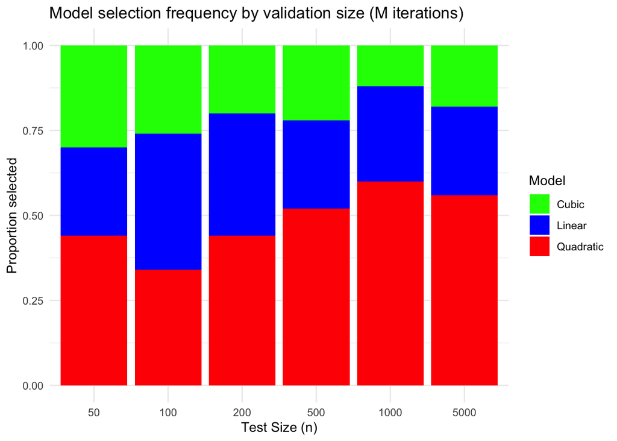

```r
# stacked bar plot of selection proportions
selection_plot_df <- selection_results %>%
  count(n_test, selected_model) %>%
  group_by(n_test) %>%
  mutate(prop = n / sum(n)) %>%
  ungroup()

ggplot(selection_plot_df, aes(x = factor(n_test), y = prop, fill = selected_model)) +
  geom_col(position = "stack") +
  scale_fill_manual(values = c("Linear" = "blue", "Quadratic" = "red", "Cubic" = "green")) +
  labs(
    title = "Model selection frequency by validation size (M iterations)",
    x = "Test Size (n)",
    y = "Proportion selected",
    fill = "Model"
  ) +
  theme_minimal()
```

## i. Confidence Intervals and Hypothesis Testing

Yes, this analysis is related to confidence intervals and hypothesis testing. We will come back to these concepts later in the course.